# Reproducible Research: Peer Assessment 1

## Introduction

This assignment makes use of data from a personal activity monitoring device. This device collects data at 5 minute intervals through out the day. The data consists of two months of data from an anonymous individual collected during the months of October and November, 2012 and include the number of steps taken in 5 minute intervals each day.

The data is downloaded from the course web site and it consists of 17,568 values for 3 variables:

- steps: Number of steps taking in a 5-minute interval (missing values are coded as NA)
- date: The date on which the measurement was taken in YYYY-MM-DD format
- interval: Identifier for the 5-minute interval in which measurement was taken

## Loading and preprocessing the data

First, we read in the data:

```r
activity <- read.csv('activity.csv')
```

Then we take a quick look at the structure of the data:

```r
str(activity)
```

```
## 'data.frame':    17568 obs. of  3 variables:
##  $ steps   : int  NA NA NA NA NA NA NA NA NA NA ...
##  $ date    : Factor w/ 61 levels "2012-10-01","2012-10-02",..: 1 1 1 1 1 1 1 1 1 1 ...
##  $ interval: int  0 5 10 15 20 25 30 35 40 45 ...
```

We create a date.time column that combines the date and interval columns:

```r
time <- formatC(activity$interval / 100, 2, format='f')
activity$date.time <- as.POSIXct(paste(activity$date, time),
                                 format='%Y-%m-%d %H.%M',
                                 tz='GMT')
head(activity)
```

```
##   steps       date interval           date.time
## 1    NA 2012-10-01        0 2012-10-01 00:00:00
## 2    NA 2012-10-01        5 2012-10-01 00:05:00
## 3    NA 2012-10-01       10 2012-10-01 00:10:00
## 4    NA 2012-10-01       15 2012-10-01 00:15:00
## 5    NA 2012-10-01       20 2012-10-01 00:20:00
## 6    NA 2012-10-01       25 2012-10-01 00:25:00
```

For analyzing the means at different times of the day, we create a time column:

```r
activity$time <- format(activity$date.time, format='%H:%M:%S')
activity$time <- as.POSIXct(activity$time, format='%H:%M:%S')
head(activity)
```

```
##   steps       date interval           date.time                time
## 1    NA 2012-10-01        0 2012-10-01 00:00:00 2014-10-19 00:00:00
## 2    NA 2012-10-01        5 2012-10-01 00:05:00 2014-10-19 00:05:00
## 3    NA 2012-10-01       10 2012-10-01 00:10:00 2014-10-19 00:10:00
## 4    NA 2012-10-01       15 2012-10-01 00:15:00 2014-10-19 00:15:00
## 5    NA 2012-10-01       20 2012-10-01 00:20:00 2014-10-19 00:20:00
## 6    NA 2012-10-01       25 2012-10-01 00:25:00 2014-10-19 00:25:00
```

## What is the mean total number of steps taken per day?

First, we calculate the total number of steps for each day:

```r
total.steps <- tapply(activity$steps, activity$date, sum, na.rm=TRUE)
```

Then we plot a histogram of the daily values:

```
## stat_bin: binwidth defaulted to range/30. Use 'binwidth = x' to adjust this.
```

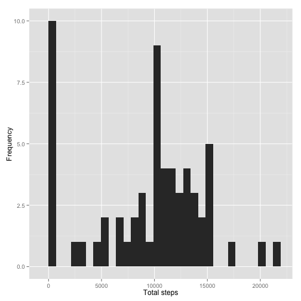

```r
library(ggplot2)
qplot(total.steps, xlab='Total steps', ylab='Frequency')
```

Next, we calculate the mean and median total steps per day:

```r
mean(total.steps)
```

```
## [1] 9354
```

```r
median(total.steps)
```

```
## [1] 10395
```

## What is the average daily activity pattern?

We first calculate the mean steps for each five minute interval and save in a new data frame:

```r
mean.steps <- tapply(activity$steps, activity$time, mean, na.rm=TRUE)
daily.pattern <- data.frame(time=as.POSIXct(names(mean.steps)),
                            mean.steps)
head(mean.steps)
```

```
## 2014-10-19 00:00:00 2014-10-19 00:05:00 2014-10-19 00:10:00
##             1.71698             0.33962             0.13208
## 2014-10-19 00:15:00 2014-10-19 00:20:00 2014-10-19 00:25:00
##             0.15094             0.07547             2.09434
```

Next, we take a look at a time series plot of the mean steps:

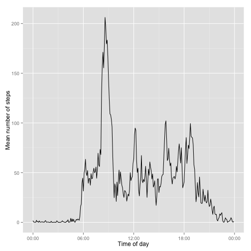

```r
library(scales)
ggplot(daily.pattern, aes(time, mean.steps)) +
    geom_line() +
    xlab('Time of day') +
    ylab('Mean number of steps') +
    scale_x_datetime(labels=date_format(format='%H:%M'))
```

Finally, we determine which five minute interval has the highest mean number of steps:

```r
most <- which.max(daily.pattern$mean.steps)
format(daily.pattern[most,'time'], format='%H:%M')
```

```
## [1] "08:35"
```

## Imputing missing values

First, we count the number of intervals with missing step counts (“NA's”):

```r
sum(is.na(activity$steps))
```

```
## [1] 2304
```

We replace each missing value with the mean steps:

```r
library(Hmisc)
# make a copy of the activity dataframe
activity.imputed <- activity
# replace the missing values with the mean
activity.imputed$steps <- with(activity.imputed, impute(steps, mean))
head(activity.imputed)
```

```
##   steps       date interval           date.time                time
## 1 37.38 2012-10-01        0 2012-10-01 00:00:00 2014-10-19 00:00:00
## 2 37.38 2012-10-01        5 2012-10-01 00:05:00 2014-10-19 00:05:00
## 3 37.38 2012-10-01       10 2012-10-01 00:10:00 2014-10-19 00:10:00
## 4 37.38 2012-10-01       15 2012-10-01 00:15:00 2014-10-19 00:15:00
## 5 37.38 2012-10-01       20 2012-10-01 00:20:00 2014-10-19 00:20:00
## 6 37.38 2012-10-01       25 2012-10-01 00:25:00 2014-10-19 00:25:00
```

We compare the mean and median steps for each day, for the original data set and the imputed data set:

```r
total.steps.imputed <- tapply(activity.imputed$steps,
                              activity.imputed$date, sum)
mean(total.steps)
```

```
## [1] 9354
```

```r
mean(total.steps.imputed)
```

```
## [1] 10766
```

```r
median(total.steps)
```

```
## [1] 10395
```

```r
median(total.steps.imputed)
```

```
## [1] 10766
```

Replacing the missing data increases both the mean and median of the total steps.

We make a simple histogram of the imputed vales:

```
## stat_bin: binwidth defaulted to range/30. Use 'binwidth = x' to adjust this.
```

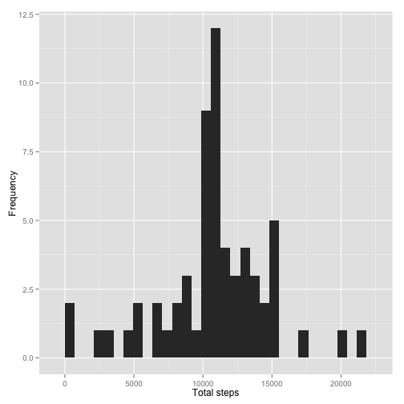

```r
qplot(total.steps.imputed, xlab='Total steps', ylab='Frequency')
```

Finally, we generate a histogram showing the overlay of the imputed dataset with the original data set:

```r
all.steps <- as.data.frame(cbind(total.steps, total.steps.imputed))
library(reshape)
melted.all.steps <- melt(all.steps)
```

```
## Using  as id variables
```

```
## stat_bin: binwidth defaulted to range/30. Use 'binwidth = x' to adjust this.
```

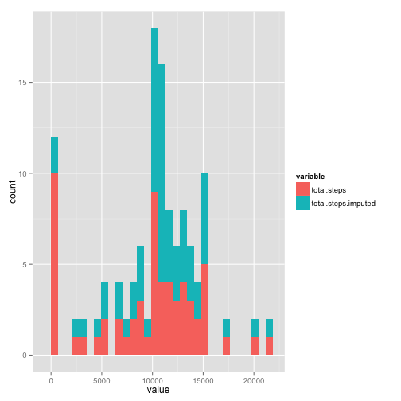

```r
qplot(value,data=melted.all.steps,fill=variable)
```

We can see that there are now more step values with the imputed data set.

## Are there differences in activity patterns between weekdays and weekends?

First we add a factor column for whether a day is a weekday or weekend:

```r
day.type <- function(date) {
    if (weekdays(date) %in% c('Saturday', 'Sunday')) {
        return('weekend')
    } else {
        return('weekday')
    }
}

day.types <- sapply(activity.imputed$date.time, day.type)
activity.imputed$day.type <- as.factor(day.types)
```

We then create a dataframe that holds the mean steps for weekdays and weekends:

```r
mean.steps <- tapply(activity.imputed$steps,
                     interaction(activity.imputed$time,
                                 activity.imputed$day.type),
                     mean, na.rm=TRUE)
day.type.pattern <- data.frame(time=as.POSIXct(names(mean.steps)),
                               mean.steps=mean.steps,
                               day.type=as.factor(c(rep('weekday', 288),
                                                   rep('weekend', 288))))
```

Next we compare the patterns between weekdays and weekends:

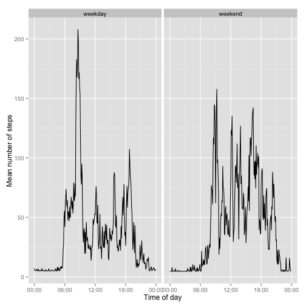

```r
ggplot(day.type.pattern, aes(time, mean.steps)) +
    geom_line() +
    xlab('Time of day') +
    ylab('Mean number of steps') +
    scale_x_datetime(labels=date_format(format='%H:%M')) +
    facet_grid(. ~ day.type)
```